# Matching Counterfactual Forest

This is the script for the assessment of the impact of different governance mechanisms on forest loss and its associated carbon emissions in the Peruvian Amazon from 2000 to 2021 done for the article “Potential of different governance mechanisms for achieving Global Biodiversity Framework goals” (Negret et al. 2024). The study evaluates the effectiveness of protected areas (PAs) and potential OECMs, particularly Indigenous Lands and Non-Timber Forest Products Concessions, in the Peruvian Amazon from 2000 to 2021. It uses a robust before-after control intervention design with statistical matching to account for non-random deforestation pressures and governance types.

The input of the script is a data table where the rows represent pixels and the columns represent covariates. You must include a column that indicates the type of governance or management area, using 1s and 0s.

Link to the article; https://www.researchsquare.com/article/rs-4170734/v1

# Load libraries

```r
# List necessary packages
packages_list<-list("magrittr", "dplyr", "plyr", "MatchIt", "RItools", "Hmisc", "this.path", "scales", "ggdendro", "data.table", "openxlsx",
                    "tibble", "leaps", "pbapply", "RColorBrewer", "ggpubr", "ggdist", "ggh4x")

# Install necessary packages not installed
packagesPrev<- .packages(all.available = TRUE)
lapply(packages_list, function(x) {   if ( ! x %in% packagesPrev ) { install.packages(x, force=T)}    })

# Load libraries
lapply(packages_list, library, character.only = TRUE)
```

```r
packages_list<-list("magrittr", "dplyr", "plyr", "ggplot2")
lapply(packages_list, library, character.only = TRUE)
```

# Define workspace

```r
# Set working directory
# Uses 'this.path::this.path()' to find the path of the current R script and 'dirname()' to get its directory. This directory is set as the working directory where the current code is stored.
dir_work<- this.path::this.path() %>% dirname()

# Set input - output folder
# Establishes paths for input and output directories relative to 'dir_work'. 'file.path()' constructs the path to the directories ensuring it is OS independent.
input<- file.path(dirname(dir_work), "input")
output<- file.path(dirname(dir_work), "output")
```

# Load data

```r
# Load data. The data should be a table where rows correspond to spatial units (e.g., pixels) and columns represent variables.
# Each spatial unit (row) will serve as the input for the matching process, which will be performed based on the similarity between covars (columns)
setwd(input)
data<- read.csv("data.csv", header = T)
```

```r
names(data)
```

```
##  [1] "X"            "Y"            "PUID"         "Carbon"       "Department"
##  [6] "Anual_Prec"   "Prec_Seas"    "Dis_Def"      "Dis_Rivers"   "District_R"
## [11] "Departme_R"   "National_R"   "D7Set10"      "D7Set1000"    "D7Set5000"
## [16] "D7Set10000"   "D17Set10"     "D17Set1000"   "D17Set5000"   "D17Set10000"
## [21] "Ecoregions"   "Elevation"    "Pop2000"      "Pop2020"      "Slope"
## [26] "Tra_Time00"   "Tra_Time15"   "Fores_2000"   "Fores_2005"   "Fores_2010"
## [31] "Fores_2021"   "Carbon_pixel" "id_rincon"    "PA"           "IL"
## [36] "CC"           "LC"           "MC"           "psvalue"
```

```r
head(data)
```

```
##           X       Y   PUID   Carbon Department Anual_Prec Prec_Seas  Dis_Def
## 178 1105751 8443292 149038 52.88590          8       2486        53 324.5000
## 183 1108463 8441966 149090 23.76750          8       2239        55 182.4830
## 193 1107703 8440151 149404 37.75690          8       2388        54  60.0000
## 200 1105832 8441130 149801 54.71670          8       2538        52 234.3070
## 209 1102617 8433531 150087  5.94987          8       1774        61  84.8528
## 215 1107531 8439304 150275 53.05250          8       2284        55 120.0000
##     Dis_Rivers District_R Departme_R National_R D7Set10 D7Set1000 D7Set5000
## 178    6829.60   12661.70    6430.51   17222.10 10786.7   34787.8    159891
## 183    7410.00    9654.59    6896.87   15998.20 11634.8   32044.3    160779
## 193    9355.77    9522.48    8846.54   14134.60 12882.7   31405.2    162674
## 200    8794.91   11615.30    8415.25   15061.10 10971.5   32715.1    162004
## 209   15216.20   14386.60   15230.00    8188.41 11930.5   24552.9    170075
## 215   10205.80    9432.84    9694.64   13281.60 12990.1   31011.4    163532
##     D7Set10000 D17Set10 D17Set1000 D17Set5000 D17Set10000 Ecoregions Elevation
```

[output cut: 20 more lines]

```r
# Specify the column name in data that defines spatial units in relation to governance type.
# This column indicates which spatial units are associated with a type of governance (1) and which are not (0).
type_gov<- "MC"
table(data[,type_gov])
```

```
##
##      0      1
## 245180    934
```

# test multicolinearity

```r
# List preliminary covariates-columns in "data" table to estimate similarity for matching.
# These are considered preliminary as they will undergo multicollinearity tests and significance checks in relation to governance type.
  covars<-c( "Department", "Anual_Prec", "Prec_Seas",  "Dis_Def",    "Dis_Rivers",
            "District_R", "Departme_R", "National_R", "D7Set10",    "D7Set1000",  "D7Set5000",  "D7Set10000", "D17Set10",   "D17Set1000", "D17Set5000",
            "D17Set10000", "Ecoregions", "Elevation",  "Pop2000",    "Pop2020",    "Slope",      "Tra_Time00", "Tra_Time15")

# Evaluate multicollinearity
formula_test_multicor<- as.formula( paste0(type_gov, "~", paste0(covars, collapse = "+")) )
test_multicor<- glm(formula_test_multicor, data = data, family = binomial()) # sort by inflacion de varianza
```

```r
print(formula_test_multicor)
```

```
## MC ~ Department + Anual_Prec + Prec_Seas + Dis_Def + Dis_Rivers +
##     District_R + Departme_R + National_R + D7Set10 + D7Set1000 +
##     D7Set5000 + D7Set10000 + D17Set10 + D17Set1000 + D17Set5000 +
##     D17Set10000 + Ecoregions + Elevation + Pop2000 + Pop2020 +
##     Slope + Tra_Time00 + Tra_Time15
```

```r
test_multicor
```

```
##
## Call:  glm(formula = formula_test_multicor, family = binomial(), data = data)
##
## Coefficients:
## (Intercept)   Department   Anual_Prec    Prec_Seas      Dis_Def   Dis_Rivers
##  -6.929e+00    6.682e-02    1.741e-04    4.758e-02   -5.745e-04   -3.001e-05
##  District_R   Departme_R   National_R      D7Set10    D7Set1000    D7Set5000
##  -5.490e-05    3.424e-05   -3.051e-05   -5.634e-05   -2.857e-05   -1.357e-05
##  D7Set10000     D17Set10   D17Set1000   D17Set5000  D17Set10000   Ecoregions
##  -1.283e-04   -5.541e-06    5.539e-05   -2.307e-05    1.621e-04   -2.827e-03
##   Elevation      Pop2000      Pop2020        Slope   Tra_Time00   Tra_Time15
##   2.292e-04    5.773e-02    6.310e-04   -6.679e-03   -2.982e-04   -1.017e-05
##
## Degrees of Freedom: 246113 Total (i.e. Null);  246090 Residual
## Null Deviance:       12280
## Residual Deviance: 8159  AIC: 8207
```

```r
# The results of this  model are organized as a correlation matrix, which displays multicollinearity among covariates with respect to the response variable typegov.
cordataR<- summary(test_multicor, correlation=T)[["correlation"]] %>% as.data.frame.matrix()
cordataR[,"(Intercept)"]<- NULL; cordataR<- cordataR[2:nrow(cordataR), ]# ELIMINAR INTERCEPT MATRIZ DE CORRELACION
NACol<- names(which(rowSums(is.na(cordataR)) > (ncol(cordataR)/2) ))
cordata<- cordataR %>% {.[!names(.) %in% NACol,]} %>% {.[,!colnames(.) %in% NACol]}; cordata[is.na(cordata)]<-0
```

```r
str(cordata)
```

```
## 'data.frame':    23 obs. of  23 variables:
##  $ Department : num  1 0.03251 0.16061 -0.00873 -0.07882 ...
##  $ Anual_Prec : num  0.03251 1 0.05158 -0.09212 -0.00162 ...
##  $ Prec_Seas  : num  0.16061 0.05158 1 0.00399 0.11367 ...
##  $ Dis_Def    : num  -0.00873 -0.09212 0.00399 1 -0.06524 ...
##  $ Dis_Rivers : num  -0.07882 -0.00162 0.11367 -0.06524 1 ...
##  $ District_R : num  -0.0418 -0.0958 0.1711 -0.0451 0.0432 ...
##  $ Departme_R : num  0.2955 -0.0331 0.0932 -0.0655 0.0164 ...
##  $ National_R : num  0.00751 0.0522 -0.05401 0.00563 0.01502 ...
##  $ D7Set10    : num  -0.09174 0.02181 -0.11619 -0.00856 -0.10002 ...
##  $ D7Set1000  : num  0.01 0.1813 -0.0592 0.0066 0.0523 ...
##  $ D7Set5000  : num  -0.0343 -0.2995 -0.3185 0.0181 -0.0757 ...
##  $ D7Set10000 : num  0.04494 0.09653 0.00911 0.01956 0.02772 ...
##  $ D17Set10   : num  -0.0516 -0.0447 -0.0273 -0.0855 -0.0549 ...
##  $ D17Set1000 : num  -0.0807 -0.0777 -0.0369 -0.0617 -0.0181 ...
##  $ D17Set5000 : num  -0.10226 0.5568 -0.0894 0.0101 -0.00855 ...
##  $ D17Set10000: num  -0.02179 -0.09182 0.04348 -0.02474 -0.00846 ...
##  $ Ecoregions : num  0.0896 0.0403 0.1631 0.021 -0.0374 ...
##  $ Elevation  : num  0.2237 0.3978 -0.41 0.0183 -0.1049 ...
##  $ Pop2000    : num  0.0506 0.0611 0.0637 0.0331 0.0263 ...
##  $ Pop2020    : num  -0.002285 -0.001836 -0.000998 0.000707 -0.003885 ...
##  $ Slope      : num  0.0852 -0.0395 -0.0197 0.0401 0.0436 ...
##  $ Tra_Time00 : num  0.0247 0.1118 0.0342 0.0104 -0.0973 ...
##  $ Tra_Time15 : num  -0.01843 0.05634 0.09136 -0.04218 -0.00846 ...
```

```r
head(cordata)
```

```
##             Department   Anual_Prec   Prec_Seas      Dis_Def   Dis_Rivers
## Department  1.00000000  0.032505326 0.160609805 -0.008725980 -0.078823328
## Anual_Prec  0.03250533  1.000000000 0.051581571 -0.092119965 -0.001618779
## Prec_Seas   0.16060980  0.051581571 1.000000000  0.003985557  0.113671007
## Dis_Def    -0.00872598 -0.092119965 0.003985557  1.000000000 -0.065241011
## Dis_Rivers -0.07882333 -0.001618779 0.113671007 -0.065241011  1.000000000
## District_R -0.04178543 -0.095832427 0.171078442 -0.045051635  0.043185133
##             District_R  Departme_R   National_R     D7Set10   D7Set1000
## Department -0.04178543  0.29552639  0.007505277 -0.09174172  0.01004060
## Anual_Prec -0.09583243 -0.03305699  0.052197735  0.02181235  0.18126409
## Prec_Seas   0.17107844  0.09321904 -0.054005574 -0.11619138 -0.05915869
## Dis_Def    -0.04505164 -0.06551750  0.005625617 -0.00856436  0.00660381
## Dis_Rivers  0.04318513  0.01638816  0.015021251 -0.10002336  0.05232755
## District_R  1.00000000 -0.09475910 -0.015679282 -0.04379188 -0.08406537
##              D7Set5000  D7Set10000    D17Set10  D17Set1000   D17Set5000
## Department -0.03430716 0.044942221 -0.05162315 -0.08074973 -0.102257217
## Anual_Prec -0.29948553 0.096534300 -0.04474397 -0.07771157  0.556799495
## Prec_Seas  -0.31851473 0.009110956 -0.02726464 -0.03689956 -0.089404325
## Dis_Def     0.01807623 0.019561263 -0.08551638 -0.06166245  0.010101990
## Dis_Rivers -0.07565404 0.027716651 -0.05494112 -0.01812928 -0.008553665
## District_R  0.14074799 0.046213909 -0.10357965 -0.19311632 -0.011802726
##             D17Set10000  Ecoregions   Elevation     Pop2000       Pop2020
## Department -0.021790893  0.08961566  0.22369355  0.05063298 -0.0022854692
## Anual_Prec -0.091821064  0.04025275  0.39776589  0.06105794 -0.0018360471
## Prec_Seas   0.043477335  0.16307552 -0.41001914  0.06366587 -0.0009979708
## Dis_Def    -0.024744125  0.02104548  0.01827189  0.03307967  0.0007072675
## Dis_Rivers -0.008457375 -0.03743994 -0.10488495  0.02627021 -0.0038845953
## District_R -0.073240915  0.02042709 -0.05908218 -0.02618374  0.0007210510
##                  Slope  Tra_Time00   Tra_Time15
## Department  0.08520488  0.02470843 -0.018431359
## Anual_Prec -0.03952660  0.11176616  0.056341197
## Prec_Seas  -0.01969954  0.03416434  0.091357560
## Dis_Def     0.04012618  0.01043568 -0.042178365
## Dis_Rivers  0.04361611 -0.09726303 -0.008464001
## District_R -0.03003442  0.07727625 -0.321160504
```

```r
# From the correlation matrix, we must decide which variables to remove to reduce multicollinearity. To achieve this, we generate groups of correlated variables using a correlation threshold.
cor_threshold<- 0.65 # define correlation threshold

# Covariate clustering
corhclust <- hclust(as.dist(1-abs(cordata)))
cordend<-as.dendrogram(corhclust)
cordend_data <- dendro_data(cordend)

# Plot dendrogram of correlated variables. The dendrogram visualizes the correlation among variables, highlighting groups of correlated covariables based on the defined correlation threshold (cor_threshold) marked by a red line.
var_table <- with(cordend_data$labels, data.frame(y_center = x, y_min= x-0.5, y_max=x+0.5, Variable = as.character(label), height = 1))
col1<- "#EBEBEB"; col2<- "white"; is.even<- function(x){ x %% 2 == 0 }
var_table$col<- rep_len(c(col1, col2), length.out=length(var_table$Variable)) %>% {if(is.even(length(.))) {rev(.)} else {.}}
segment_data <- with(segment(cordend_data), data.frame(x = y, y = x, xend = yend, yend = xend, cor= 1-yend))

ggdendroPlot <-   ggplot()+
  annotate("rect", xmin = -0.05, xmax = 1.04, fill = var_table$col,ymin = var_table$y_min , ymax = var_table$y_max, alpha = 0.75 )+
  geom_segment(data= segment_data, aes(x = 1-x, y = y, xend = 1-xend, yend = yend, label= cor), size= 0.3)+
  scale_y_continuous(breaks = cordend_data$labels$x,  labels = cordend_data$labels$label )+
  coord_cartesian(expand = F)+
  labs(x= "Correlation", y= "Variables") +
  geom_vline(xintercept = cor_threshold, linetype = "dashed", col= "red") +
  theme(legend.position =  "bottom", legend.key.width = unit(50, 'pt'),
        plot.margin = margin(t = 0, r = 0,  b = 0,l = 0),
        panel.grid.major = element_line(color = "gray"),
        axis.ticks.length   = unit(0.3, "mm"),
        text = element_text(size = 10))
```

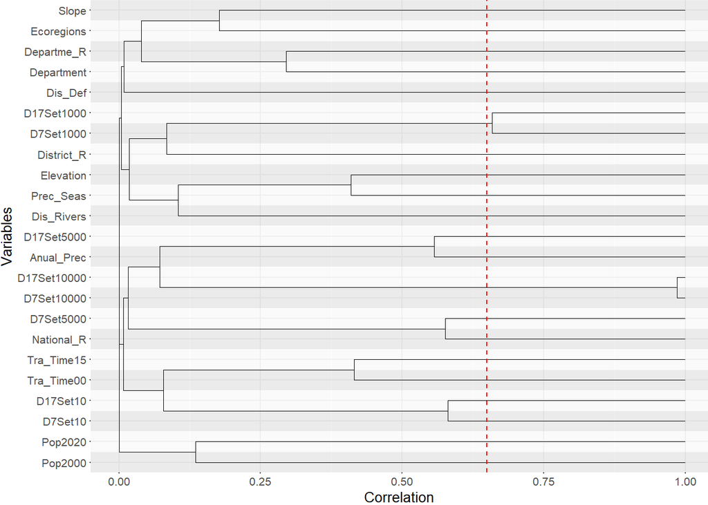

```r
print(ggdendroPlot)
```

```r
  # Remove high-correlated variables. Following exploration, we select one variable per group to reduce multicollinearity, choosing the variable with the lowest VIF in each group.
vif_data<- car::vif(test_multicor) %>% as.data.frame() %>% {data.frame(Var= rownames(.), VIF= .[,1])} %>% arrange(VIF)
vif_values <-  vif_data %>%
    dplyr::mutate(Variable1= Var, VIF_var1= VIF, Variable2= Var, VIF_var2= VIF) %>%  dplyr::arrange("VIF")
rank_covars<- cutree(corhclust, h = 1-cor_threshold) %>% as.data.frame %>% rownames_to_column("Var") %>% setnames(".", "group") %>%
      dplyr::filter(!Var %in% "(Intercept)") %>% list(vif_data) %>% join_all() %>% arrange(group, VIF)

covars_no_multicol<- dplyr::filter(rank_covars, !duplicated(group))$Var
```

```r
print(rank_covars)
```

```
##            Var group         VIF
## 1   Department     1    1.686904
## 2   Anual_Prec     2    5.044480
## 3    Prec_Seas     3    2.576239
## 4      Dis_Def     4    1.187174
## 5   Dis_Rivers     5    1.174632
## 6   District_R     6    2.221542
## 7   Departme_R     7    1.459723
## 8   National_R     8    2.609948
## 9      D7Set10     9    2.735404
## 10   D7Set1000    10    3.106596
## 11  D17Set1000    10    3.245172
## 12   D7Set5000    11   33.898956
## 13  D7Set10000    12 1059.526642
## 14 D17Set10000    12 1076.676371
## 15    D17Set10    13    2.622886
## 16  D17Set5000    14    2.271917
## 17  Ecoregions    15    2.053750
## 18   Elevation    16    4.997142
## 19     Pop2000    17    1.126313
## 20     Pop2020    18    1.019657
## 21       Slope    19    1.890821
## 22  Tra_Time00    20    1.756650
## 23  Tra_Time15    21    3.058327
```

```r
print(covars_no_multicol)
```

```
##  [1] "Department" "Anual_Prec" "Prec_Seas"  "Dis_Def"    "Dis_Rivers"
##  [6] "District_R" "Departme_R" "National_R" "D7Set10"    "D7Set1000"
## [11] "D7Set5000"  "D7Set10000" "D17Set10"   "D17Set5000" "Ecoregions"
## [16] "Elevation"  "Pop2000"    "Pop2020"    "Slope"      "Tra_Time00"
## [21] "Tra_Time15"
```

```r
# Optimization and adjustment for selecting the best model ####
pre_formula_glm<- as.formula( paste0(type_gov, "~", paste0(covars_no_multicol, collapse = "+")) ) # new formula with variables that do not exhibit multicollinearity
```

```r
print(pre_formula_glm)
```

```
## MC ~ Department + Anual_Prec + Prec_Seas + Dis_Def + Dis_Rivers +
##     District_R + Departme_R + National_R + D7Set10 + D7Set1000 +
##     D7Set5000 + D7Set10000 + D17Set10 + D17Set5000 + Ecoregions +
##     Elevation + Pop2000 + Pop2020 + Slope + Tra_Time00 + Tra_Time15
```

```r
  # Estimate forward and backward models. adds and removes variables through multiple iterations to find the optimal model that balances complexity with predictive power. We use AIC to select the best model.
model  <- regsubsets(pre_formula_glm, data = data, nvmax = length(covars), method = "seqrep")
summ_model<-summary(model)[c("rsq", "rss", "adjr2", "cp", "bic" )] %>% as.data.frame() %>% dplyr::mutate(model= seq(nrow(.)))
list_models<- seq(nrow(summ_model))
AIC_models<- pblapply(list_models, function(x){
    coefs<- coef(model, id = x) # get coefficients
    vars<- names(coefs)[-1] # get vars
    form_test<- as.formula( paste0(type_gov, "~", paste0(vars, collapse = "+")) ) # organize form
    glm_test<- glm(form_test, data = data, family = binomial()) # run glm
    data_AIC<- data.frame(model= x, AIC= extractAIC(glm_test)[2]) # get AIC
    data_vars <- data.frame(model= x, vars= vars) # get data vars
    data_form<- data.frame(model= x, formula = paste0(type_gov, "~", paste0(vars, collapse = "+")) ) # get data forms
    list(data_AIC=data_AIC, data_vars=data_vars, data_form= data_form )   })

# Ranking models
# Compiles the formulas of models evaluated by AIC into a single dataframe for easy comparison.
forms_models<- rbind.fill(purrr::map(AIC_models, "data_form"))
```

```r
print(forms_models)
```

```
##    model
## 1      1
## 2      2
## 3      3
## 4      4
## 5      5
## 6      6
## 7      7
## 8      8
## 9      9
## 10    10
## 11    11
## 12    12
## 13    13
## 14    14
```

[output cut: 29 more lines]

```r
  # Aggregates AIC information, merges it with summary model data, and ranks models based on BIC and AIC values to identify the best performers.
better_models<- rbind.fill(purrr::map(AIC_models, "data_AIC")) %>% list(summ_model) %>% join_all() %>%
    dplyr::arrange( bic) %>% dplyr::mutate(rank_BIC= seq(nrow(.))) %>%
    dplyr::arrange(AIC) %>% dplyr::mutate(rank_AIC= seq(nrow(.)))
```

```r
print(better_models)
```

```
##    model       AIC         rsq      rss       adjr2         cp       bic
## 1     19  8558.893 0.023772632 908.3361 0.023697261   18.08911 -5673.173
## 2     20  8560.805 0.023772918 908.3358 0.023693580   20.01681 -5660.832
## 3     21  8562.537 0.023772985 908.3358 0.023689680   22.00000 -5648.435
## 4     18  8585.160 0.023771519 908.3371 0.023700116   16.36953 -5685.306
## 5     17  8588.001 0.023765157 908.3431 0.023697720   15.97347 -5696.115
## 6     16  8592.222 0.023481595 908.6069 0.023418106   85.45513 -5637.052
## 7     14  8623.559 0.022279442 909.7255 0.022223822  384.49942 -5359.084
## 8     15  8665.919 0.023714604 908.3901 0.023655098   24.71696 -5708.198
## 9     13  8766.380 0.023611744 908.4858 0.023560167   46.64644 -5707.097
## 10    12  8785.059 0.018706667 913.0498 0.018658819 1281.14188 -4486.204
## 11    11  8828.707 0.023454286 908.6323 0.023410638   82.33909 -5692.237
## 12    10  8851.177 0.023347485 908.7317 0.023307801  107.26204 -5677.736
## 13     5  9124.066 0.019660996 912.1618 0.019641079 1026.57003 -4812.566
## 14     9  9130.066 0.023232825 908.8384 0.023197104  134.16627 -5661.257
```

[output cut: 29 more lines]

```r
# Selection of the best model
# Allows the researcher to review the ranked models based on selected criteria (default: AIC)
critera<- "AIC" # DEFAULT

# Collates variables from the best AIC models, ranks them by frequency of appearance, and prepares them for visualization analysis.
data_vars<-  rbind.fill(purrr::map(AIC_models, "data_vars")) %>% list(better_models) %>%
    join_all() %>%  dplyr::group_by(vars) %>% dplyr::mutate(freq_var= n()) %>%
    dplyr::arrange(freq_var) %>% dplyr::mutate(vars= factor(vars, levels = unique(.$vars)) )

# Organizes and ranks models based on the selected criterion preparing for the selection of the best model.
vars_models<- data_vars %>% dplyr::arrange(eval(sym(critera))) %>%
    dplyr::mutate(model= factor(model, levels = unique(.$model)) ) %>% as.data.frame()


# Identifies the best model based on the ranking, setting it aside for in-depth analysis and use in matching.
better_model<- unique(vars_models[1,1])
```

```r
print(better_model)
```

```
## [1] 19
## Levels: 19 20 21 18 17 16 14 15 13 12 11 10 5 9 7 8 4 6 3 1 2
```

```r
# Selected variables for the best model
selected_variables<- data_vars %>% dplyr::arrange(eval(sym(critera))) %>%
  dplyr::filter(model %in% better_model) %>% {as.character(.$vars)}
```

```r
print(selected_variables)
```

[output not shown]

```r
  # Plot best models' AIC by variable. The heatmap displays the top-performing models horizontally and the most impactful variables vertically. Warmer hues indicate superior AIC values, illustrating the effectiveness of each variable within the highest-ranked models as per the chosen metric (AIC).
plot_better_model<-  ggplot()+
    geom_tile(data= vars_models, aes(x= model , y= vars, fill = eval(sym(critera)) ), color="black", alpha= 0.5, size=0.2)+
    scale_fill_gradientn(critera, colors = brewer.pal(11, "Spectral"))
```

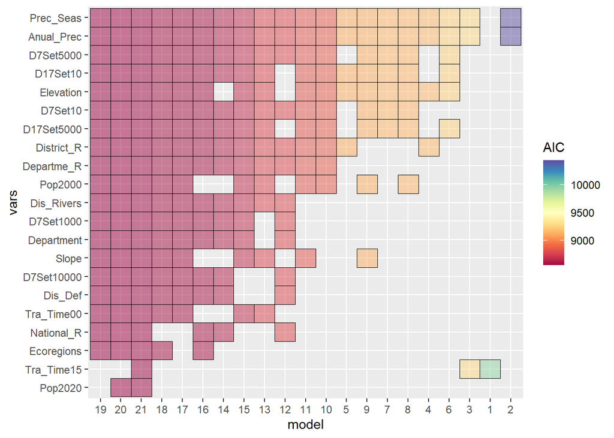

```r
print(plot_better_model)
```

# Pre-matching exploratory analysis

This phase involves analyzing distributions and assessing the balance of variables across the typegov groups. It provides an initial diagnostic of the data, setting the stage for understanding the impact of the matching process.

```r
  # Propensity scores calculation.
  # Identifies the 'treated' group based on 'type_gov' == 1, then calculates the standardized differences for selected variables before matching.
treated <-(data[,type_gov] ==1)
cov <-data[,selected_variables]
std.diff <-apply(cov,2,function(x) 100*(mean(x[treated])- mean(x[!treated]))/(sqrt(0.5*(var(x[treated]) + var(x[!treated]))))) %>% abs()

# Generate a propensity score model
formula_glm<- as.formula( paste0(type_gov, "~", paste0(selected_variables, collapse = "+")) )
```

```r
print(formula_glm)
```

```
## MC ~ Ecoregions + National_R + Tra_Time00 + Dis_Def + D7Set10000 +
##     Department + D7Set1000 + Slope + Dis_Rivers + Pop2000 + Departme_R +
##     District_R + D7Set10 + D17Set5000 + D7Set5000 + D17Set10 +
##     Elevation + Anual_Prec + Prec_Seas
```

```r
ps <- glm(formula_glm, data = data, family = binomial())

# Estimate propensity scores predicted by the logistic model.
data$psvalue <- predict(ps, type = "response")

# Organizes standardized differences for easy analysis and visualization, highlighting variables with the most imbalance.
PreMatchingIndexData<- data.frame(abs(std.diff)) %>% set_names("imbalance") %>% tibble::rownames_to_column(var="Variable") %>%  arrange(imbalance)

  # A good balance is considered to be less than 25%. For visualization purposes, imbalances greater than 100% are capped at 100%. # An imbalance over 25% indicates significant differences in group characteristics.

PreMatchingIndexDataV2<- PreMatchingIndexData  %>%  arrange(desc(imbalance)) %>%
    mutate(imbalance= ifelse(imbalance>=100,100,imbalance)) %>%
    mutate(Variable= factor(Variable, levels = unique(.$Variable)), label= paste0(paste(paste(rep("   ",3), collapse = ""), collapse = ""), Variable, sep=""))
```

```r
print(PreMatchingIndexDataV2)
```

```
##      Variable imbalance               label
## 1  National_R 100.00000          National_R
## 2  Tra_Time00 100.00000          Tra_Time00
## 3  District_R 100.00000          District_R
## 4   Prec_Seas 100.00000           Prec_Seas
## 5    D17Set10 100.00000            D17Set10
## 6     D7Set10 100.00000             D7Set10
## 7     Dis_Def 100.00000             Dis_Def
## 8  D17Set5000 100.00000          D17Set5000
## 9   D7Set1000 100.00000           D7Set1000
## 10 Departme_R  87.26923          Departme_R
## 11 D7Set10000  77.11723          D7Set10000
## 12  Elevation  72.17227           Elevation
## 13 Dis_Rivers  68.86277          Dis_Rivers
## 14 Ecoregions  63.22910          Ecoregions
## 15      Slope  54.36166               Slope
## 16 Department  51.04086          Department
## 17  D7Set5000  47.47929           D7Set5000
## 18    Pop2000  29.05575             Pop2000
## 19 Anual_Prec  27.15450          Anual_Prec
```

# Execute matching analysis

```r
 # Performs matching based on the specified criteria
  # The 'formula_glm' defines the treatment indicator and covariates for matching, 'method = "nearest"'.
m.nn <- matchit(formula_glm, data =data, method= "nearest", ratio = 1)
```

```r
# Extracts the matched dataset and calculates the deforestation indicator. 'deforest' is defined as 1 if the forest status changed from present ('Fores_2000' == 1) to absent ('Fores_2021' == 0) over the study period, and 0 otherwise.
  y=match.data(m.nn, group="all")

# Propensity scores calculation.
treated1 <-(y[, type_gov]==1)

cov1 <-y[, selected_variables]
std.diff1 <-apply(cov1,2,function(x) 100*(mean(x[treated1])- mean(x[!treated1]))/(sqrt(0.5*(var(x[treated1]) + var(x[!treated1])))))

# Organizes standardized differences for easy analysis and visualization
posmatchingIndexData<- data.frame(abs(std.diff1)) %>% set_names("imbalance") %>% tibble::rownames_to_column(var="Variable") %>%  arrange(imbalance)
posmatchingIndexDataV2<- posmatchingIndexData  %>%  arrange(desc(imbalance)) %>%
  mutate(imbalance= ifelse(imbalance>=100,100,imbalance)) %>%
  mutate(Variable= factor(Variable, levels = unique(.$Variable)), label= paste0(paste(paste(rep("   ",3), collapse = ""), collapse = ""), Variable, sep=""))

# Estimate percent balance improvement. Organize the standardized differences before and after matching data.
summ_Imbalancedata<- plyr::rbind.fill(list( dplyr::mutate(PreMatchingIndexDataV2, Match= "Unmatched"),  dplyr::mutate(posmatchingIndexDataV2, Match= "Matched")))


# Plotting imbalance data. The plot demonstrates the improvements in variable imbalance before and after matching.

y_axis_title_unbalanced_vars_posmatch<- "Index of covariate imbalance"
x_axis_title_unbalanced_vars_posmatch<- "Variables"
legend_title_unbalanced_vars_posmatch<- "Pixeles de la ventana"
plot_title_unbalanced_vars_posmatch<- "Pos Matching"
color_vline_unbalanced_vars_posmatch<- "red"
pos_vline_unbalanced_vars_posmatch<- 25

gg_summ_Imbalancedata<- ggplot(data= summ_Imbalancedata)+
  geom_point(aes(x=imbalance, y= Variable, color= Match), size= 1) +
  labs(x= y_axis_title_unbalanced_vars_posmatch, y= x_axis_title_unbalanced_vars_posmatch)+
  geom_vline(aes(xintercept= pos_vline_unbalanced_vars_posmatch),  size= 0.5, linetype="dashed", color = color_vline_unbalanced_vars_posmatch)+
  theme(
    plot.margin = margin(t = 0, r = 0,  b = 0,l = 0),
    axis.ticks.length   = unit(0.3, "mm"),
    text = element_text(size = 10),
    panel.background = element_rect(fill = NA), panel.grid.major = element_line(color = "gray"),
    axis.line = element_line(size = 0.5, colour = "black") )+
  scale_x_continuous(expand = c(0,0), limits = c(0,110))+
  ggtitle(type_gov)
```

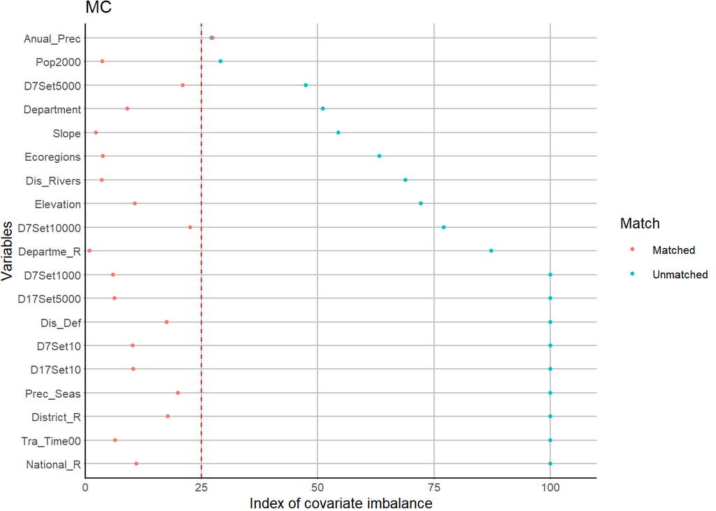

```r
print(gg_summ_Imbalancedata)
```

# Plotting Imbalance Figure.

This plot visualizes the distribution of propensity scores before and after matching through histograms.

```r
  # Splitting the pre-matching data based on the 'type_gov' variable to compare groups inside and outside the treatment condition.
includedListPreMatching <- split(data, data[, type_gov])

# Set graphic parameters for pre-matching histograms.
in_area_prematch <- list(title= paste0("In ", type_gov), color= "goldenrod")
out_area_prematch <- list(title= paste0("Out ", type_gov), color= "olivedrab")
y_axis_title_prematch <- "Number of Units"
x_axis_title_prematch <- "Propensity Score"
legend_title_prematch <- "Window Pixels"
plot_title_prematch <- "Pre Matching"

# Create pre-matching plot.
PreMatchversusplot <- ggplot(data = includedListPreMatching[["0"]]) +
  geom_histogram(data = includedListPreMatching[["1"]], aes(x = psvalue, y = ..count..,
                                                            fill = in_area_prematch$title, color = in_area_prematch$title)) +
  geom_histogram(aes(x = psvalue, y = -..count.., fill = out_area_prematch$title, color = out_area_prematch$title)) +
  scale_y_continuous(labels = abs) +
  scale_fill_manual(values = alpha(c(out_area_prematch$color, in_area_prematch$color), 0.5), name = legend_title_prematch) +
  scale_color_manual(values = alpha(c(out_area_prematch$color, in_area_prematch$color), 1), name = legend_title_prematch) +
  labs(x = x_axis_title_prematch, y = y_axis_title_prematch, title = plot_title_prematch) +
  guides(size = "none", fill = guide_legend(title.position="top", title.hjust = 0.5)) +
  theme_minimal() + theme(legend.position = "bottom", text = element_text(size = 10))

# Splitting the post-matching data.
includedListposmatching <- split(y, y[, type_gov])

# Set graphic parameters for post-matching histograms.
in_area_posmatch <- list(title= paste0("In ", type_gov), color= "goldenrod")
out_area_posmatch <- list(title= paste0("Out ", type_gov), color= "olivedrab")
y_axis_title_posmatch <- "Number of Units"
x_axis_title_posmatch <- "Propensity Score"
legend_title_posmatch <- "Window Pixels"
plot_title_posmatch <- "Post Matching"

# Create post-matching plot.
posmatchversusplot <- ggplot(data = includedListposmatching[["0"]]) +
  geom_histogram(data = includedListposmatching[["1"]], aes(x = psvalue, y = ..count..,
                                                            fill = in_area_posmatch$title, color = in_area_posmatch$title)) +
  geom_histogram(aes(x = psvalue, y = -..count.., fill = out_area_posmatch$title, color = out_area_posmatch$title)) +
  scale_y_continuous(labels = abs) +
  scale_fill_manual(values = alpha(c(out_area_posmatch$color, in_area_posmatch$color), 0.5), name = legend_title_posmatch) +
  scale_color_manual(values = alpha(c(out_area_posmatch$color, in_area_posmatch$color), 1), name = legend_title_posmatch) +
  labs(x = x_axis_title_posmatch, y = y_axis_title_posmatch, title = plot_title_posmatch) +
  scale_x_continuous(limits = c(0, 1)) +
  guides(size = "none", fill = guide_legend(title.position="top", title.hjust = 0.5)) +
  theme_minimal() + theme(legend.position = "bottom", text = element_text(size = 10))

# Arrange pre and post matching plots together for comparison.
summ_matching_propension_plot <- ggpubr::ggarrange(plotlist = list(PreMatchversusplot, posmatchversusplot), common.legend = T, legend = "bottom")
```

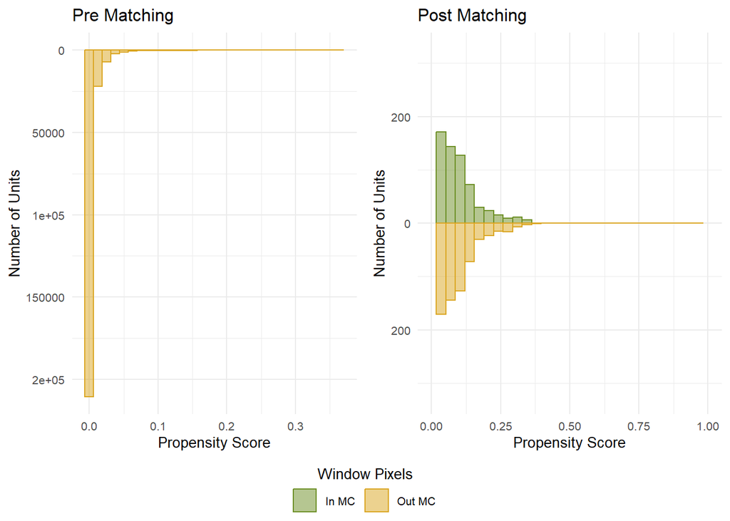

```r
print(summ_matching_propension_plot)
```

```r
test_multicor
```

```
##
## Call:  glm(formula = formula_test_multicor, family = binomial(), data = data)
##
## Coefficients:
## (Intercept)   Department   Anual_Prec    Prec_Seas      Dis_Def   Dis_Rivers
##  -6.929e+00    6.682e-02    1.741e-04    4.758e-02   -5.745e-04   -3.001e-05
##  District_R   Departme_R   National_R      D7Set10    D7Set1000    D7Set5000
##  -5.490e-05    3.424e-05   -3.051e-05   -5.634e-05   -2.857e-05   -1.357e-05
##  D7Set10000     D17Set10   D17Set1000   D17Set5000  D17Set10000   Ecoregions
##  -1.283e-04   -5.541e-06    5.539e-05   -2.307e-05    1.621e-04   -2.827e-03
##   Elevation      Pop2000      Pop2020        Slope   Tra_Time00   Tra_Time15
##   2.292e-04    5.773e-02    6.310e-04   -6.679e-03   -2.982e-04   -1.017e-05
##
## Degrees of Freedom: 246113 Total (i.e. Null);  246090 Residual
## Null Deviance:       12280
## Residual Deviance: 8159  AIC: 8207
```

# Analysis post-matching

Outputs from the matched groups are evaluated. We assessed changes per pixel in relation to forests and carbon in 2000 and 2021

```r
# Map the matched groups
# Retrieve matching pairs from the 'matchit' result to align the treatment (T) and control (C) groups for further analysis.
matches <- data.frame(m.nn$match.matrix)
group1 <- match(row.names(matches), row.names(y))
group2 <- match(matches[, 1], row.names(y))
```

```r
# Estimate forest and carbon trends ####

########### Forests effect
# Extract forest status data for the treated T group at different time points.
forest_yT2000 <- y$Fores_2000[group1]
forest_yT2021 <- y$Fores_2021[group1]

# Extract forest status data for the control C group at different time points.
forest_yC2000 <- y$Fores_2000[group2]
forest_yC2021 <- y$Fores_2021[group2]

########### Carbon effect
carbon_yt<- y$Carbon_pixel[group1]
carbon_yC<- y$Carbon_pixel[group2]

## summ match
matched.cases_forest <- cbind(matches, forest_yT2000, forest_yT2021, forest_yC2000, forest_yC2021, carbon_yt, carbon_yC)
```

# Organize control data

```r
# control_pre matching. Use the entire dataset to define the control group before matching to understand baseline conditions.
Control <- data[data[,type_gov] %in% 0, ]
control_pre_forest_2020 =sum(Control$Fores_2000)
control_pre_forest_2021 =sum(Control$Fores_2021)

# Calculate the proportion of forest pixels that remained unchanged in the control group pre-matching.
Prop_noloss_forest_control_pre= (control_pre_forest_2021/control_pre_forest_2020)*100
# Calculate the proportion of forest loss in the control group pre-matching.
Prop_forest_control_pre= 100-Prop_noloss_forest_control_pre

# Estimate confidence intervals for forest loss proportion in the control group pre-matching.
# The DescTools::BinomCI function computes confidence intervals for binomial proportions, providing a range of values within which the true proportion is likely to lie.https://rdrr.io/cran/DescTools/man/BinomCI.html
binomial_test_control_pre<- 100* (1 - DescTools::BinomCI(x= control_pre_forest_2021, n= length(Control$Fores_2000),
                                                           conf.level = 0.95, method = "wilson" )) %>% as.data.frame()
lower_def_control_pre<- min(binomial_test_control_pre[c("lwr.ci", "upr.ci")])
upper_def_control_pre<- max(binomial_test_control_pre[c("lwr.ci", "upr.ci")])

# control_pos matching. Define the control group from the data after matching analysis.
control_pos_forest_2020 = sum(matched.cases_forest$forest_yC2000)
control_pos_forest_2021 = sum(matched.cases_forest$forest_yC2021)

# Calculate the proportion of forest pixels that remained unchanged in the control group pos-matching.
Prop_noloss_forest_control_pos= (control_pos_forest_2021/control_pos_forest_2020)*100

# Calculate the proportion of forest loss in the control group pos-matching.
Prop_forest_control_pos= 100-Prop_noloss_forest_control_pos


# Estimate confidence intervals for forest loss proportion in the control group pos-matching.
binomial_test_control_pos<- 100* (1 - DescTools::BinomCI(x= control_pos_forest_2021, n= length(matched.cases_forest$forest_yT2000),
                                                         conf.level = 0.95, method = "wilson" )) %>% as.data.frame()
lower_def_control_pos<- min(binomial_test_control_pos[c("lwr.ci", "upr.ci")])
upper_def_control_pos<- max(binomial_test_control_pos[c("lwr.ci", "upr.ci")])
```

# Organize treatment data

```r
# Define the treatment group from the data after matching analysis.
treatment_forest_2020 = sum(matched.cases_forest$forest_yT2000)
treatment_forest_2021 = sum(matched.cases_forest$forest_yT2021)

# Calculate the proportion of forest pixels that remained unchanged in the treatment group pos-matching.
Prop_noloss_forest_treatment = (treatment_forest_2021 / treatment_forest_2020) * 100

# Calculate the proportion of forest loss in the treatment group pos-matching.
Prop_forest_treatment = 100 - Prop_noloss_forest_treatment

# Estimate confidence intervals for forest loss proportion in the treatment group pos-matching.
binomial_test_treat<- 100* (1 - DescTools::BinomCI(x= treatment_forest_2021, n= length(matched.cases_forest$forest_yT2000),
                                                   conf.level = 0.95, method = "wilson" )) %>% as.data.frame()

# Estimate confidence intervals for forest loss proportion in the treatment group pos-matching.
lower_def_treat<- min(binomial_test_treat[c("lwr.ci", "upr.ci")])
upper_def_treat<- max(binomial_test_treat[c("lwr.ci", "upr.ci")])
```

# Estimation of treatment significance - governance type

```r
# Model to assess changes in forest status from 2000 to 2021 as a function of governance type and selected variables.

sign_form_treatment<- as.formula(paste0("cbind(Fores_2000,Fores_2021)", paste0("~", type_gov, "+"), paste(selected_variables, collapse= "+")))

# Fit a glm to the matched data to evaluate the effect of governance and other covariates on forest status.
Model_M_forest = glm( sign_form_treatment , data = y ,family = binomial)
Model_M_forest_deviance<- deviance(Model_M_forest)
Model_M_forest_AIC<- extractAIC(Model_M_forest)[2]
Model_M_forest_sum<- summary(Model_M_forest)

# Fit a model focused on forest changes from 2000 to 2021 as influenced by governance type alone, simplifying the influence of other variables.
formula_M_forest_2000_2021<- as.formula(paste0("cbind(Fores_2000,Fores_2021)", paste0("~", type_gov)))
Model_M_forest_2000_2021 = glm(formula_M_forest_2000_2021, data = y ,family = binomial)
Model_M_forest_2000_2021_deviance<- deviance(Model_M_forest_2000_2021)
Model_M_forest_2000_2021_AIC<- extractAIC(Model_M_forest_2000_2021)[2]
Model_M_forest_2000_2021_sum <- summary(Model_M_forest_2000_2021)
sign_Model_M_forest_2000_2021_sum<- Model_M_forest_2000_2021_sum$coefficients[2,4]

# Fit a glm to the matched data to evaluate the effect of governance and other covariates on forest status.
formula_M_forest_covs<- as.formula(paste0("cbind(Fores_2000,Fores_2021)", paste0("~", type_gov, "+"), paste(selected_variables, collapse= "+")))
Model_M_forest_covs = glm( formula_M_forest_covs , data = y ,family = binomial)
Model_M_forest_covs_deviance<- deviance(Model_M_forest_covs)
Model_M_forest_covs_AIC<- extractAIC(Model_M_forest_covs)[2]
Model_M_forest_covs_sum<- summary(Model_M_forest_covs)
sign_Model_M_forest_covs_sum<- Model_M_forest_covs_sum$coefficients[2,4]

formula_M_forest_2000_2021; formula_M_forest_covs;

# Organize forest analysis data
# This table summarizes forest data for treatment and control groups pre- and post-matching, detailing forest loss, non-loss proportions, their confidence intervals, and statistical significance
summary_forest<- data.frame(fd= c("treatment", "control_pre", "control_pos"),
                              forest_2000_2020= c(treatment_forest_2020 , control_pre_forest_2020, control_pos_forest_2020),
                              forest_2000_2021= c(treatment_forest_2021 , control_pre_forest_2021, control_pos_forest_2021),
                              forest_prop_noloss= c(Prop_noloss_forest_treatment , Prop_noloss_forest_control_pre, Prop_noloss_forest_control_pos),
                              forest_prop_loss= c(Prop_forest_treatment , Prop_forest_control_pre, Prop_forest_control_pos),
                              low_interval= c(lower_def_treat, lower_def_control_pre, lower_def_control_pos ),
                              upper_interval= c(upper_def_treat, upper_def_control_pre, upper_def_control_pos ),
                              zval_M_forest_2000_2021 = c(sign_Model_M_forest_2000_2021_sum, NA, NA)  ) %>%
    dplyr::mutate(type= type_gov, fd= factor(fd, levels=  c("treatment", "control_pos", "control_pre"))) %>%
      dplyr::mutate(sign_forest_2000_2021= sapply(.$zval_M_forest_2000_2021, function(x) {
      if(is.na(x)){""}else if(x<0.001){"***"}else if(x<0.05){"**"}else if(x<0.1){"*"} else {""} })  )
```

```r
print(summary_forest)
```

```
##            fd forest_2000_2020 forest_2000_2021 forest_prop_noloss
## 1   treatment              934              717           76.76660
## 2 control_pre           245180           233577           95.26756
## 3 control_pos              934              768           82.22698
##   forest_prop_loss low_interval upper_interval zval_M_forest_2000_2021 type
## 1        23.233405    20.637945       26.04814               0.3232083   MC
## 2         4.732441     4.649102        4.81720                      NA   MC
## 3        17.773019    15.454819       20.35523                      NA   MC
##   sign_forest_2000_2021
## 1
## 2
## 3
```

```r
# Plotting forest estimations
# Define the colors and labels for the plotting
guide_fill_forest<- list(
  data.frame(fd= "control_pre", label_fill= "Control preMatching", color_fill= "lightskyblue1"),
  data.frame(fd= "control_pos", label_fill = "Control posMatching", color_fill= "rosybrown1"),
  data.frame(fd= "treatment", label_fill = "Treatment", color_fill = "lightgoldenrodyellow")
) %>% rbind.fill()

guide_xaxis_forest <- list(
  data.frame(fd= "control_pre", label_x= "Control preMatching" ),
  data.frame(fd= "control_pos", label_x = "Control posMatching" ),
  data.frame(fd= "treatment", label_x = "Treatment" )
) %>% rbind.fill()

y_axis_title_result_forest<- "Forest loss (%)"
x_axis_title_result_forest<- type_gov
legend_title_result_forest<- ""
plot_title_result_forest<- paste("Forests", type_gov)

dataplot_forest<- summary_forest %>%
  dplyr::mutate(fd= factor( fd, levels = unique(.$fd) )) %>%
  list(guide_fill_forest, guide_xaxis_forest) %>% plyr::join_all() %>%
  dplyr::mutate(
    label_fill= factor(label_fill, unique(guide_fill_forest$label_fill)),
    label_x= factor(label_x, levels= unique(guide_xaxis_forest$label_x))
  )

y_pos<- max(dataplot_forest$upper_interval)+1;

# plot the proportion of forest loss
plot_forest<- ggplot(data= dataplot_forest,  aes(x= label_x, y= forest_prop_loss , fill= label_fill))+
  geom_bar(stat = "identity", width = 0.4, size= 0.1, position = position_dodge(width  = .8)) +
  geom_errorbar(aes(ymin = low_interval, ymax = upper_interval),
                width = 0.1, position =  position_dodge(width  = .8), color = "black")+
  xlab(x_axis_title_result_forest)+ylab(y_axis_title_result_forest)+
  scale_y_continuous(limits = c(0,100), labels = function(x) paste0(x, "%")) +
  scale_fill_manual(legend_title_result_forest,  values = setNames(guide_fill_forest$color_fill ,guide_fill_forest$label_fill) )+
  theme_minimal()+
  theme(legend.position = "bottom",
        axis.text.x  = element_blank(),
        axis.line.y = element_line(color = "black"),
        axis.line.x = element_line(color = "black"))
```

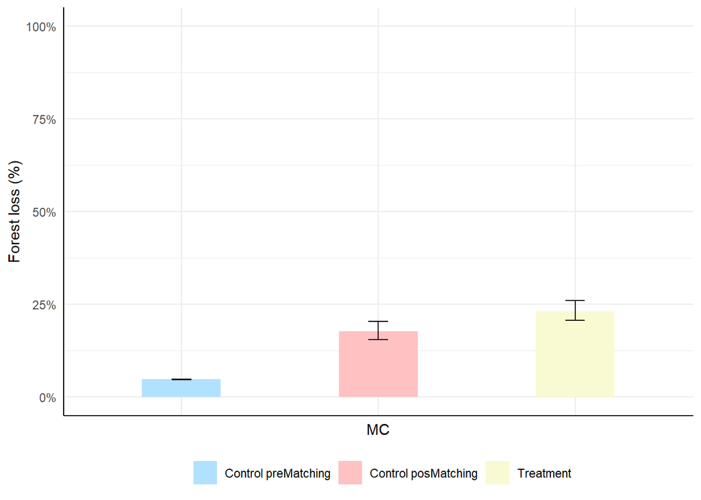

```r
print(plot_forest)
```

```r
# Calculate the delta of forest loss for labeling on the plot
max_forest_summary<- summary_forest$upper_interval %>%  {max(., na.rm = T)+abs(sd(.))} # valor maximo barra
ylimits_forest_summary<- c(0, max_forest_summary)

# plot the proportion of forest loss   with significance annotations

plot_forest_sign <- ggplot(data= dataplot_forest,  aes(x= label_x, y= forest_prop_loss , fill= label_fill))+
  geom_bar(stat = "identity", width = 0.4, size= 0.1, position = position_dodge(width  = .8)) +
  geom_errorbar(aes(ymin = low_interval, ymax = upper_interval),
                width = 0.1, position =  position_dodge(width  = .8), color = "black")+
  geom_signif(y_position = y_pos, xmin = c(2.5-0.4), xmax = c(2.5+0.4), tip_length = c(0.01, 0.01), size=0.3,   annotation = dataplot_forest$sign_forest_2000_2021[1] )+
xlab(x_axis_title_result_forest)+ylab(y_axis_title_result_forest)+
  scale_y_continuous(limits = ylimits_forest_summary, labels = function(x) paste0(x, "%")) +
  scale_fill_manual(legend_title_result_forest,  values = setNames(guide_fill_forest$color_fill ,guide_fill_forest$label_fill) )+
  theme_minimal()+
  theme(legend.position = "bottom",
        axis.text.x  = element_blank(),
        axis.line.y = element_line(color = "black"),
        axis.line.x = element_line(color = "black"))
```

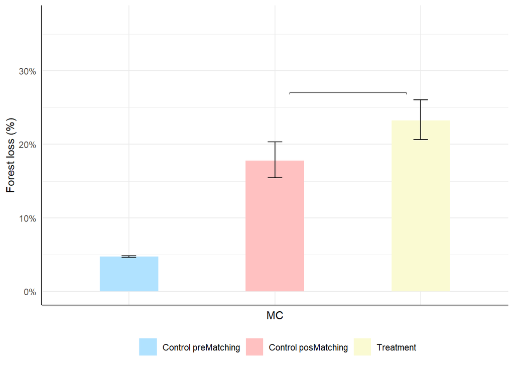

```r
print(plot_forest_sign)
```

```r
########### Carbon effect

# Pre-matching control
control_pre_carbon_2000 = dplyr::filter(Control, Fores_2000 == 1)$Carbon_pixel
control_pre_carbon_2021 = dplyr::filter(Control, Fores_2021 == 1)$Carbon_pixel

# Identify carbon pixel data associated with deforestation from 2000 to 2021 from original data
loss_pre_carbon<- dplyr::filter(Control, Fores_2000 == 1 & Fores_2021 == 0 )$Carbon_pixel

# Calculate metrics about carbon in deforestation pixels.
mean_pre_carbon<- mean(loss_pre_carbon)
sum_pre_carbon<- sum(loss_pre_carbon)

sum_control_pre_carbon_2000<- sum(control_pre_carbon_2000, na.rm=T)
sum_control_pre_carbon_2021<- sum(control_pre_carbon_2021, na.rm=T)

mean_control_pre_carbon_2000<- mean(control_pre_carbon_2000, na.rm=T)
mean_control_pre_carbon_2021<- mean(control_pre_carbon_2021, na.rm=T)


# Calculate the proportion of carbon retained and lost in pixels with forests before matching.
Prop_noloss_carbon_control_pre<- (sum_control_pre_carbon_2021/sum_control_pre_carbon_2000)*100
Prop_carbon_control_pre<- 100-Prop_noloss_carbon_control_pre

# Estimate confidence intervals for carbon loss proportion in the control group pre-matching.
binomial_test_losscarb_control_pre<- 100* (1 - DescTools::BinomCI(x= sum_control_pre_carbon_2021, n= sum(control_pre_carbon_2000, na.rm=T),
                                                           conf.level = 0.95, method = "wilson" )) %>% as.data.frame()

lower_losscarb_control_pre<- min(binomial_test_losscarb_control_pre[c("lwr.ci", "upr.ci")])
upper_losscarb_control_pre<- max(binomial_test_losscarb_control_pre[c("lwr.ci", "upr.ci")])

# Organize data
dispersion_pre_carbon_effect <- list(t1= control_pre_carbon_2000, t2= control_pre_carbon_2021, loss= loss_pre_carbon) %>%
    {lapply(names(.), function(x) data.frame(level= x, value= .[[x]]))} %>% rbind.fill() %>%
    dplyr::mutate(level= factor(level, levels= c("t1", "t2", "loss")), treatment= "control_pre")



##  Pos-matching control
  control_pos_carbon_2000 = dplyr::filter(matched.cases_forest, forest_yC2000 == 1)$carbon_yC
  control_pos_carbon_2021 = dplyr::filter(matched.cases_forest, forest_yC2021 == 1)$carbon_yC

# Identify carbon pixel data associated with deforestation from 2000 to 2021 from matching data
loss_pos_carbon<- dplyr::filter(matched.cases_forest, forest_yC2000 == 1 & forest_yC2021 == 0 )$carbon_yt


# Calculate metrics about carbon in deforestation pixels.
  mean_pos_carbon<- mean(loss_pos_carbon)
  sum_pos_carbon<- sum(loss_pos_carbon)

  sum_control_pos_carbon_2000<- sum(control_pos_carbon_2000, na.rm=T)
  sum_control_pos_carbon_2021<- sum(control_pos_carbon_2021, na.rm=T)

  mean_control_pos_carbon_2000<- mean(control_pos_carbon_2000, na.rm=T)
  mean_control_pos_carbon_2021<- mean(control_pos_carbon_2021, na.rm=T)

  # Calculate the proportion of carbon retained and lost in pixels with forests after matching.
  Prop_noloss_carbon_control_pos<- (sum_control_pos_carbon_2021/sum_control_pos_carbon_2000)*100
  Prop_carbon_control_pos<- 100-Prop_noloss_carbon_control_pos


  # Estimate confidence intervals for carbon loss proportion in the control group pos-matching.
  binomial_test_losscarb_control_pos<- 100* (1 - DescTools::BinomCI(x= sum_control_pos_carbon_2021, n= sum(control_pos_carbon_2000, na.rm=T),
                                                                    conf.level = 0.95, method = "wilson" )) %>% as.data.frame()

  lower_losscarb_control_pos<- min(binomial_test_losscarb_control_pos[c("lwr.ci", "upr.ci")])
  upper_losscarb_control_pos<- max(binomial_test_losscarb_control_pos[c("lwr.ci", "upr.ci")])

  # Organize data
  dispersion_pos_carbon_effect <- list(t1= control_pos_carbon_2000, t2= control_pos_carbon_2021, loss= loss_pos_carbon) %>%
    {lapply(names(.), function(x) data.frame(level= x, value= .[[x]]))} %>% rbind.fill() %>%
    dplyr::mutate(level= factor(level, levels= c("t1", "t2", "loss")), treatment= "control_pos")


##  Pos-matching treatment
  treatment_pos_carbon_2000 = dplyr::filter(matched.cases_forest, forest_yT2000 == 1)$carbon_yt
  treatment_pos_carbon_2021 = dplyr::filter(matched.cases_forest, forest_yT2021 == 1)$carbon_yt

  # Calculate metrics about carbon in deforestation pixels.
  mean_pos_carbon<- mean(loss_pos_carbon)
  sum_pos_carbon<- sum(loss_pos_carbon)

  sum_treatment_pos_carbon_2000<- sum(treatment_pos_carbon_2000, na.rm=T)
  sum_treatment_pos_carbon_2021<- sum(treatment_pos_carbon_2021, na.rm=T)

  mean_treatment_pos_carbon_2000<- mean(treatment_pos_carbon_2000, na.rm=T)
  mean_treatment_pos_carbon_2021<- mean(treatment_pos_carbon_2021, na.rm=T)


  loss_treatment_pos_carbon<- dplyr::filter(matched.cases_forest, forest_yT2000 == 1 & forest_yT2021 == 0 )$carbon_yt
  mean_treatment_pos_carbon<- mean(loss_treatment_pos_carbon)
  sum_treatment_pos_carbon<- sum(loss_treatment_pos_carbon)

  # Calculate the proportion of carbon retained and lost in pixels with forests after matching.
  Prop_noloss_carbon_treatment_pos<- (sum_treatment_pos_carbon_2021/sum_treatment_pos_carbon_2000)*100
  Prop_carbon_treatment_pos<- 100-Prop_noloss_carbon_treatment_pos


  # Estimate confidence intervals for carbon loss proportion in the treatment group pos-matching.
  binomial_test_losscarb_treatment_pos<- 100* (1 - DescTools::BinomCI(x= sum_treatment_pos_carbon_2021, n= sum(treatment_pos_carbon_2000, na.rm=T),
                                                                    conf.level = 0.95, method = "wilson" )) %>% as.data.frame()

  lower_losscarb_treatment_pos<- min(binomial_test_losscarb_treatment_pos[c("lwr.ci", "upr.ci")])
  upper_losscarb_treatment_pos<- max(binomial_test_losscarb_treatment_pos[c("lwr.ci", "upr.ci")])

  # Organize data
  dispersion_carbon_effect <- list(t1= treatment_pos_carbon_2000, t2= treatment_pos_carbon_2021, loss= loss_pos_carbon) %>%
    {lapply(names(.), function(x) data.frame(level= x, value= .[[x]]))} %>% rbind.fill() %>%
    dplyr::mutate(level= factor(level, levels= c("t1", "t2", "loss")), treatment= "treatment_pos")

  # Organize carbon analysis data
    # This table summarizes carbon data for treatment and control groups pre- and post-matching, detailing carbon loss, non-loss proportions, their confidence intervals, and statistical significance.
  summary_carbon<- data.frame(fd= c("treatment", "control_pos", "control_pre"),
                              sum_carbon_t1= c(sum_treatment_pos_carbon_2000, sum_control_pos_carbon_2000 , sum_control_pre_carbon_2000),
                              sum_carbon_t2= c(sum_treatment_pos_carbon_2021, sum_control_pos_carbon_2021 , sum_control_pre_carbon_2021),
                              sum_carbon= c(sum_treatment_pos_carbon, sum_pos_carbon, sum_pre_carbon),
                              sum_carbon_prop_noloss= c(Prop_noloss_carbon_treatment_pos, Prop_noloss_carbon_control_pos , Prop_noloss_carbon_control_pre),
                              sum_carbon_prop_loss= c(Prop_carbon_treatment_pos, Prop_carbon_control_pos , Prop_carbon_control_pre),
                              mean_carbon_t1= c(mean_treatment_pos_carbon_2000, mean_control_pos_carbon_2000 , mean_control_pre_carbon_2000),
                              mean_carbon_t2= c(mean_treatment_pos_carbon_2021, mean_control_pos_carbon_2021 , mean_control_pre_carbon_2021),
                              mean_pixel = c(mean_treatment_pos_carbon, mean_pos_carbon, mean_pre_carbon),
                              low_interval= c(lower_losscarb_treatment_pos, lower_losscarb_control_pos, lower_losscarb_control_pre),
                              upper_interval= c(upper_losscarb_treatment_pos, upper_losscarb_control_pos, upper_losscarb_control_pre)
                              )
```

```r
print(summary_carbon)
```

```
##            fd sum_carbon_t1 sum_carbon_t2 sum_carbon sum_carbon_prop_noloss
## 1   treatment      5268.872      4096.003  1172.8689               77.73966
## 2 control_pos      5641.489      4819.597   935.7762               85.43129
## 3 control_pre   2051840.275   1990864.218 60976.0569               97.02823
##   sum_carbon_prop_loss mean_carbon_t1 mean_carbon_t2 mean_pixel low_interval
## 1            22.260340       5.641191       5.712697   5.404926    21.157527
## 2            14.568714       6.040138       6.275517   5.637206    13.672222
## 3             2.971774       8.368710       8.523374   5.255198     2.948627
##   upper_interval
## 1      23.403573
## 2      15.513425
## 3       2.995097
```

```r
# Plotting carbon estimations
  # Define the colors and labels for the plotting
  guide_fill_carbon<- list(
    data.frame(fd= "control_pre", label_fill= "Control preMatching", color_fill= "lightskyblue1"),
    data.frame(fd= "control_pos", label_fill = "Control posMatching", color_fill= "rosybrown1"),
    data.frame(fd= "treatment", label_fill = "Treatment", color_fill = "lightgoldenrodyellow")
  ) %>% rbind.fill()

  guide_xaxis_carbon <- list(
    data.frame(fd= "control_pre", label_x= "Control preMatching"),
    data.frame(fd= "control_pos", label_x= "Control posMatching"),
    data.frame(fd= "treatment", label_x = "Treatment")
  ) %>% rbind.fill()

  y_axis_title_result_carbon<- c(expression(CO[2]~"emissions (%)"))
  x_axis_title_result_carbon<- type_gov
  legend_title_result_carbon<- ""
  plot_title_result_carbon<- paste("Carbon", type_gov)

  dataplot_carbon<- summary_carbon %>%
    dplyr::mutate(fd= factor( fd, levels = unique(.$fd) )) %>%
    list(guide_fill_carbon, guide_xaxis_carbon) %>% plyr::join_all() %>%
    dplyr::mutate( label_fill= factor(label_fill, unique(guide_fill_carbon$label_fill)),
                   label_x= factor(label_x, levels= unique(guide_xaxis_carbon$label_x)) )

  # plot the proportion of carbon loss
  plot_loss_carbon_fin<- ggplot(data= dataplot_carbon,  aes(x= label_x, y= sum_carbon_prop_loss , fill= label_fill))+
    geom_bar(stat = "identity", width = 0.4, size= 0.1, position = position_dodge(width  = .8)) +
    geom_errorbar(aes(ymin = low_interval, ymax = upper_interval),
                  width = 0.1, position =  position_dodge(width  = .8), color = "black")+
    xlab(x_axis_title_result_carbon)+ylab(y_axis_title_result_carbon)+
    scale_y_continuous(limits = c(0,100), labels = function(x) paste0(x, "%")) +
    scale_fill_manual(legend_title_result_carbon,  values = setNames(guide_fill_carbon$color_fill ,guide_fill_carbon$label_fill) )+
    theme_minimal()+
    theme(legend.position = "bottom",
          axis.text.x  = element_blank(),
          axis.line.y = element_line(color = "black"),
          axis.line.x = element_line(color = "black"))
```

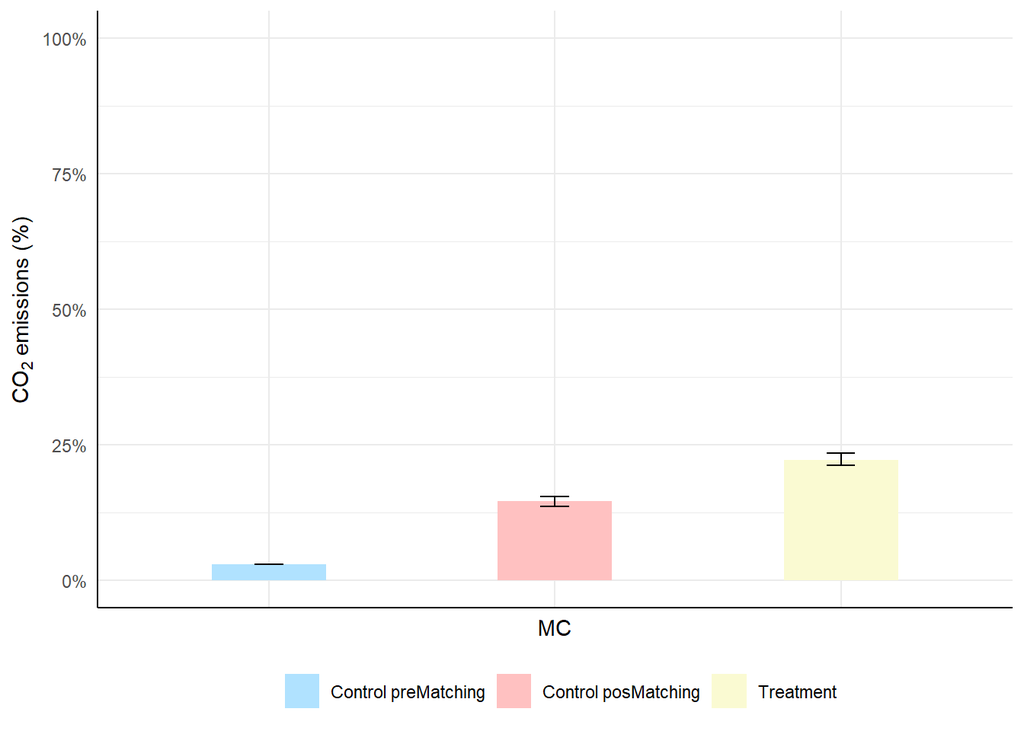

```r
print(plot_loss_carbon_fin)
```

```r
## Plotting carbon and forest estimations summary plot
  # Define the colors and labels for the plotting
  y_secondaxis_carbon_summary<- c(expression(CO[2]~"emissions (%)"))
  legend_label_carbon_summary<- c(expression(CO[2]~"emissions (%)")) # etiqueta de carbon en leyenda
  color_bar_carbon_summary<- "red" # ancho de barra carbon
  alpha_bar_carbon_summary<- 0.5 # transparencia barra carbon
  size_bar_carbon_summary<- 1 # grosor de barra carbon
  height_bar_carbon_summary<- 1 # altura de barra carbon
  size_point_carbon_summary<- 3 # grosor de barra carbon


  # Organize and Prepare Data for Combined Carbon and Forest Plot
  dataplot_carbon_bars<-   summary_carbon %>%
    list(guide_xaxis_forest, guide_fill_forest) %>% join_all() %>%
    dplyr::mutate(
      label_fill= factor(label_fill, unique(guide_fill_forest$label_fill)),
      label_x= factor(label_x, levels= unique(guide_xaxis_forest$label_x))) %>%
    dplyr::select(label_x, sum_carbon_prop_loss, label_fill, sum_carbon_prop_loss ) %>% dplyr::distinct() %>%
    group_by(label_x) %>% dplyr::mutate(n_level= n_distinct(label_fill), numeric_level= as.numeric(label_x) ) %>% as.data.frame()


  # Calculate Percentage Change in Forest Loss (Delta)
  delta_summary_forest<- {
    data_delta<-  dataplot_forest %>% dplyr::filter(!fd %in% "control_pre")
    denominador<- max( data_delta$forest_prop_loss )
    numerador<- min( data_delta$forest_prop_loss )
    delta <- (1-(numerador / denominador)) *100
    type<- data_delta %>% split(.$label_fill)
    sentido<- ifelse(  type$Treatment$forest_prop_loss >= type$`Control posMatching`$forest_prop_loss, "red", "darkgreen" )
    data.frame(label_x= type_gov, delta= delta, color= sentido)
  }

# Annotation for Delta in Forest Loss on the Forest Summary Plot
  forest_summary_sign_plot<-  plot_forest_sign +
    geom_text(x=2.5, y= y_pos, label= paste0(round(delta_summary_forest$delta, 0), "%"), size= 4, vjust= -2.5, color= delta_summary_forest$color)
```

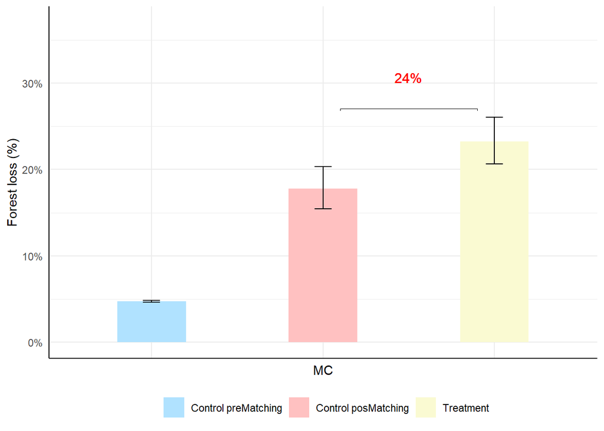

```r
print(forest_summary_sign_plot)
```

```r
 # Create Combined Plot for Carbon Emissions and Forest Loss
  forest_carbon_summary_sign_plot<-   plot_forest_sign+ ggnewscale::new_scale_fill()+
    geom_errorbarh(data= dataplot_carbon_bars,
                   aes(x= label_x,
                       xmin= dplyr::if_else(n_level > 1, numeric_level - 0.4, numeric_level - 0.2) ,
                       xmax= dplyr::if_else(n_level > 1, numeric_level + 0.4, numeric_level + 0.2), y= sum_carbon_prop_loss, group = label_fill, color= color_bar_carbon_summary  ),
                   height= height_bar_carbon_summary, position = position_dodge(0.9, preserve = 'total'), stat="identity", size= size_bar_carbon_summary, alpha= alpha_bar_carbon_summary )+
    geom_point(data= dataplot_carbon_bars,
               aes(x= label_x, y= sum_carbon_prop_loss,  group= label_fill, color= color_bar_carbon_summary ), alpha=alpha_bar_carbon_summary,
               position =  position_dodge(0.9, preserve = 'total') , size= size_point_carbon_summary, shape = 18 )  +
    scale_color_manual("", labels = legend_label_carbon_summary, values =  color_bar_carbon_summary )  +
    scale_y_continuous(sec.axis = sec_axis(~., name = y_secondaxis_carbon_summary ), limits = ylimits_forest_summary )+
    annotate(geom="text", x= 2.5, y= y_pos, label= paste0(round(delta_summary_forest$delta, 0), "%"), size= 4, vjust= -2.5, color= delta_summary_forest$color)
```

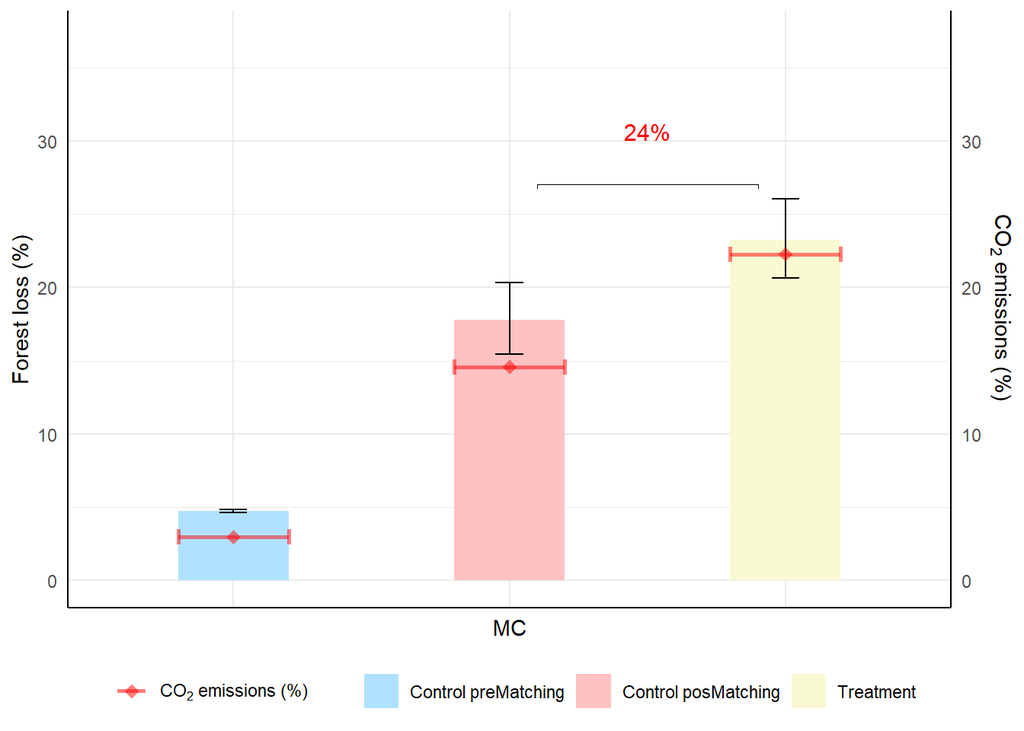

```r
print(forest_carbon_summary_sign_plot)
```

# Plotting carbon disperssion estimations

```r
# Define the colors and labels for the plotting
 # Define the colors and labels for the plotting

  guide_fill_carbon_disperssion<- list(
    data.frame(treatment= "control_pre", label_fill= "Control preMatching", color_fill= "lightskyblue1"),
    data.frame(treatment= "control_pos", label_fill = "Control posMatching", color_fill= "rosybrown1"),
    data.frame(treatment= "treatment_pos", label_fill = "Treatment", color_fill = "lightgoldenrodyellow")
    ) %>% rbind.fill()

  guide_xaxis_carbon_disperssion<- list(
    data.frame(level= "t1", label_x= "Forests 2000"),
    data.frame(level= "t2", label_x= "Forests 2021"),
    data.frame(level= "loss", label_x = "Forest 2021- Forest 2000")) %>%
    rbind.fill()

  y_axis_title_result_carbon_disperssion<- expression(Tons~of~CO[2]~" by pixel")
  x_axis_title_result_carbon_disperssion<- "Forest Over Time"
  legend_title_result_carbon_disperssion<- ""
  plot_title_result_carbon_disperssion<- paste("Carbon ", type_gov)

  # Organize data
  dataplot_carbon_disperssion <- list(dispersion_pre_carbon_effect,
                                      dispersion_pos_carbon_effect,
                                      dispersion_carbon_effect) %>%
    rbind.fill() %>% dplyr::mutate(treatment= factor( treatment, levels = unique(.$treatment) )) %>%
    list(guide_fill_carbon_disperssion, guide_xaxis_carbon_disperssion) %>% plyr::join_all() %>%
    dplyr::mutate(label_x= factor(label_x, unique(guide_xaxis_carbon_disperssion$label_x)),
                  label_fill= factor(label_fill, unique(guide_fill_carbon_disperssion$label_fill))
                  )

  limits_axis_y<- boxplot.stats(dataplot_carbon_disperssion$value)$stats %>% {c(min(.), max(.))}
  dataplot_carbon_disperssion_t1_t2<- dplyr::filter(dataplot_carbon_disperssion, !level %in% "loss")
  dataplot_carbon_disperssion_loss<- dplyr::filter(dataplot_carbon_disperssion, level %in% "loss")

  # plot the disperssion of carbon by pixel between two periods
  plot_carbon_disperssion_t1_t2<- ggplot(dataplot_carbon_disperssion_t1_t2, aes(x = label_x, y = value, fill= label_fill)) +
    geom_boxplot(width = 0.2, outlier.alpha=0, size= 0.1,
                 position = position_dodge(width  = .8),show.legend = FALSE)+
    scale_fill_manual(legend_title_result_carbon_disperssion, values = setNames(guide_fill_carbon_disperssion$color_fill,
                                                                    guide_fill_carbon_disperssion$label_fill) )+
    guides(fill_ramp = "none")  +
    scale_y_continuous(limits= limits_axis_y)+
    labs(x = x_axis_title_result_carbon_disperssion, y = y_axis_title_result_carbon_disperssion)+
    theme_minimal()+
    theme(
      axis.text.y = element_text(angle = 90, hjust = 1),
          axis.line.y = element_line(color = "black"),
          axis.line.x = element_line(color = "black"))

  # plot for carbon loss dispersion pixels
  plot_carbon_disperssion_loss<- ggplot(dataplot_carbon_disperssion_loss, aes(x = label_x, y = value, fill= label_fill)) +
    geom_boxplot(width = 0.2, outlier.alpha=0, size= 0.1,
                 position = position_dodge(width  = .8),show.legend = FALSE)+
    scale_fill_manual(legend_title_result_carbon_disperssion, values = setNames(guide_fill_carbon_disperssion$color_fill,
                                                                    guide_fill_carbon_disperssion$label_fill)
                      )+
    guides(fill_ramp = "none")  +
    scale_y_continuous(limits= limits_axis_y)+
    labs(x = "Carbon loss", y = expression("Delta Time"~ Tons~of~CO[2]~" by pixel") )+
    theme_minimal()+
    theme(
      axis.text.y = element_text(angle = 90, hjust = 1),
          axis.line.y = element_line(color = "black"),
          axis.line.x = element_line(color = "black"))




  # Display the final compiled disperssion carbon plot
  plot_carbon_final<- ggarrange(plotlist = list(
                                                plot_carbon,
                                                plot_loss_carbon_fin+theme(axis.text.x = element_blank(),axis.title.x = element_blank()),
                                             plot_carbon_disperssion_t1_t2,
                                             plot_carbon_disperssion_loss),
                                      common.legend = T, legend = "bottom", nrow = 2, ncol=2 )
```

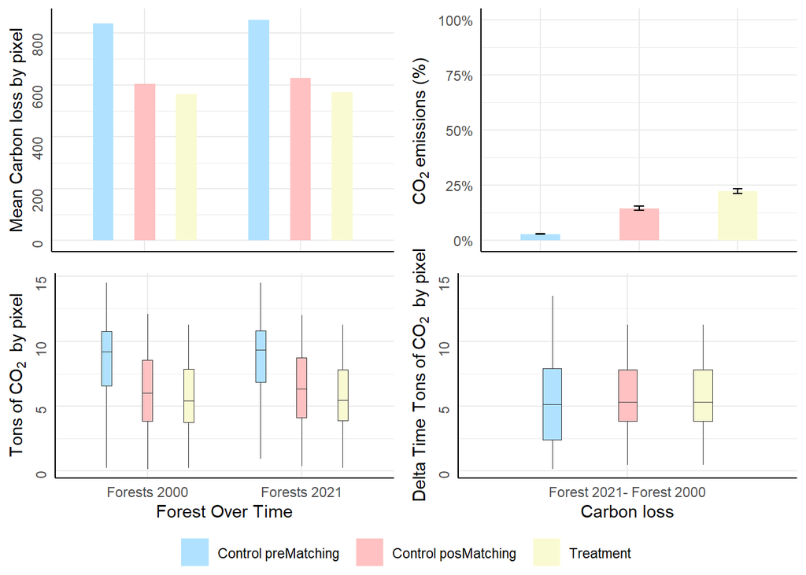

```r
print(plot_carbon_final)
```

# Plotting supplementary information

```r
# Load supplementary data
  file_supplementary<- file.path(input,   "supplementary_data_example.xlsx")
  file_sheets <- openxlsx::getSheetNames(file_supplementary)
  list_supplementary<- lapply(file_sheets, function(x) { openxlsx::read.xlsx(file_supplementary, x) }) %>% setNames(file_sheets)
  list_supplementary_data<- list_supplementary[!names(list_supplementary) %in% "Area"]

  data_supplementary<- pblapply(names(list_supplementary_data), function(i){
    data_gov <- list_supplementary_data[[i]] %>%  melt(id.vars = "Year", variable.name = "Gov_type", value.name = "value") %>%
      dplyr::filter(!is.na(value)) %>% dplyr::mutate(Data_type= i)
  }) %>% plyr::rbind.fill()

  # Set up graphical parameters for supplementary figures
  # Base Parameters
  x_axis_title_supplementary<- "Year"
  xaxix_angle_supplementary<- 0
  yaxix_angle_supplementary<- 0
  legend_title_supplementary<- "Governance\ntype"
  legend_CO2_supplementary<- c(expression(CO[2]))
  size_text_supplementary<- 10
  legend_CO2_type_gov<- c(expression(CO[2]~"loss (%)"))


  #### Specifies custom theme, color and label settings
  guide_fill_supplementary <- data.frame(Gov_type= "type_gov", vertical_title= "type_gov", color_fill= "#8D8D8D") %>%
    list(dplyr::mutate(list_supplementary$Area)) %>% plyr::join_all() %>% dplyr::mutate(label_fill= paste0(vertical_title, " (", Area, ")"))
  ylimits_supplementary <- data.frame(Gov_type= "type_gov", vertical_title= "type_gov", color_fill= "#8D8D8D",  ymincol1= NA, ymaxcol1= NA, ymincol2= NA, ymaxcol2= NA, ymincol3= NA, ymaxcol3= NA) %>%
    list(guide_fill_supplementary) %>% plyr::join_all()
  ylimits_type_gov<- ylimits_supplementary


  theme_supplementary<- function() { theme_minimal(base_size= size_text_supplementary) + theme(
    legend.position = "bottom",
    axis.ticks.x = element_line(color = "black", size = 0.5),
    axis.ticks.y = element_line(color = "black", size = 0.5),
    axis.text.x = element_text(angle = xaxix_angle_supplementary, vjust = 0.5),
    axis.text.y = element_text(angle = yaxix_angle_supplementary, vjust = 0.5),
    axis.line.y = element_line(color = "black"),
    axis.line.x = element_line(color = "black")) }

  y_axis_titles_supplementary <- list(
    data.frame(Data_type= "Forest", y_title = 'expression( "Forest Loss (" * km^2*")" )' ),
    data.frame(Data_type= "ForestProportion", y_title = "Forest Loss (%)" ),
    data.frame(Data_type= "ForestProportion_from2000", y_title = "Forest Loss\nProportional to 2000 (%)"),
    data.frame(Data_type= "CarbonTonnes", y_title = 'expression("Tonnes of " ~CO[2]~"emissions")' ),
    data.frame(Data_type= "CarbonProportion", y_title = 'expression(~CO[2]~"emissions (%)")' ),
    data.frame(Data_type= "CarbonProportion_from2000", y_title = 'expression(atop(CO[2] ~ "emissions", "proportional to 2000 (%)"))' )
  ) %>% rbind.fill()


  # Organize data for visualization
  supplementary_dataplot<- data_supplementary %>%
    list(guide_fill_supplementary, y_axis_titles_supplementary) %>% plyr::join_all()  %>%
    dplyr::mutate(label_fill= factor(label_fill, unique(guide_fill_supplementary$label_fill)),
                  Gov_type= factor(Gov_type, unique(guide_fill_supplementary$Gov_type)),
                  Data_type= factor(Data_type, unique(y_axis_titles_supplementary$Data_type))) %>%
    dplyr::filter(Year>=2000)   %>% dplyr::filter(!is.na(Gov_type)) %>% dplyr::filter(!is.na(Data_type))


  type_gov_forest_dataplot<- supplementary_dataplot %>% dplyr::filter(grepl("Forest", Data_type))
  type_gov_carbon_dataplot<- supplementary_dataplot %>% dplyr::filter(grepl("Carbon", Data_type))

  list_type_gov_forest_dataplot<- type_gov_forest_dataplot %>% split(.$Data_type) %>% {Filter(function(x) nrow(x)>0, .)}
  list_type_gov_carbon_dataplot<- type_gov_carbon_dataplot %>% split(.$Data_type) %>% {Filter(function(x) nrow(x)>0, .)}



  #### Generar plot completo
  list_type_gov_plot<- pblapply(seq_along(list_type_gov_forest_dataplot), function(i){ print(i)


    grid_forest_dataplot<- list_type_gov_forest_dataplot[[i]]
    grid_carbon_dataplot<- list_type_gov_carbon_dataplot[[i]]

    range_grid_forest<- grid_forest_dataplot$value %>% {c(min(.), max(.))}
    range_grid_carbon<- grid_carbon_dataplot$value %>% {c(min(.), max(.))}

    grid_carbon_dataplot2<- grid_carbon_dataplot %>% dplyr::mutate(value2= scales::rescale(value, to = range_grid_forest ), Data_type= unique(grid_forest_dataplot$Data_type) )

    ygrid_lab<- unique(grid_forest_dataplot$y_title)  %>% {tryCatch(eval(parse(text = .)), error=  function(e){.})}
    ygrid_secondlab<- unique(grid_carbon_dataplot$y_title) %>% {tryCatch(eval(parse(text = .)), error=  function(e){.})}

    grid_ylimits<- lapply(ylimits_supplementary[, paste0(c("ymincol", "ymaxcol"), i)] %>% split(seq(nrow(.))), function(x) {
      scale_y_continuous(limits = unlist(x), sec.axis = sec_axis(~ scales::rescale(., from= range_grid_forest, to = range_grid_carbon), name = ygrid_secondlab))  })




    grid_plot<- ggplot() +
      geom_bar(data= grid_forest_dataplot, aes(x = Year, y = value, fill= label_fill),
               stat = "identity", position = position_dodge2(preserve= "single", width=1), drop= T) +
      geom_line(data= grid_carbon_dataplot2, aes(x = Year, y = value2, color= "red"), size= 0.5) +
      geom_point(data= grid_carbon_dataplot2, aes(x = Year, y = value2, color= "red"), size= 0.5)  +
      scale_color_manual("", labels = legend_CO2_type_gov, values = c("red")) +
      scale_fill_manual( legend_title_supplementary, drop= F, values = setNames(guide_fill_supplementary$color_fill ,guide_fill_supplementary$label_fill))+
      guides(fill = guide_legend(order = 1), color = guide_legend(order = 2))+
      facet_grid2(Gov_type~Data_type, axes = "all", scales = "free",  independent = "all")+
      ylab(  ygrid_lab    )+ xlab("") +
      theme_supplementary()+theme(strip.text = element_blank())+
      ggh4x::facetted_pos_scales(y = grid_ylimits)


  })


  list_type_gov_plot[[2]]<- list_type_gov_plot[[2]] + xlab(x_axis_title_supplementary)

  vertical_titles_type_govplot<-  ggarrange(plotlist = lapply( unique(guide_fill_supplementary$vertical_title) , function(x)
  {ggplot() +  annotate("text", x = 0, y = 0.1, label = x, angle = 90, vjust = 1, size= 3)+ theme_void() + theme(axis.title.x = element_text())+xlab("")   }), ncol = 1)

  complete_type_gov_plot<- ggarrange(plotlist = list_type_gov_plot, nrow   = 1,legend=  "bottom", common.legend = T)
```

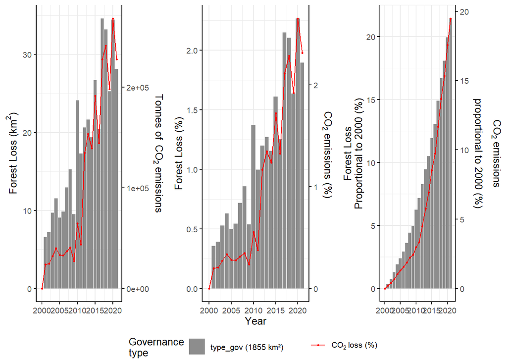

```r
print(complete_type_gov_plot)
```